# Proyecto Análisis Estadístico de Datos - PCA y FA

Santiago López e Isabella Martínez

# PCA Y FA

Este notebook busca realizar una reduccion de la dimensionalidad de cada uno de los datasets (musica, peliculas y hobbies) trabajados por medio de un analisis de componentes principales y un analisis de factores.

Empecemos importando las librerias necesarios

```r
options(warn=-1)

# Para graficar
library(ggbiplot)
```

Ahora procedamos a leer los datos y a organizarlos

```r
dat <- read.csv("../../DATA/responses.csv", header = TRUE, encoding = "UTF-8", sep = ",")

# Convertimos los datos NaN a 0
dat[is.na(dat)] = 0

# musica
dat_music = dat[,2:19]

# peliculas
dat_movies = dat[,21:31]

# hobbies
dat_hobbies = dat[,32:63]
```

# PCA

## MUSICA

Vamos a hacer componentes principales

```r
pca_music <- princomp(dat_music)
summary(pca_music)
```

```
Importance of components:
                          Comp.1    Comp.2    Comp.3     Comp.4     Comp.5     Comp.6
Standard deviation     2.4472373 2.0567127 1.7165715 1.34364914 1.29771078 1.20547257
Proportion of Variance 0.2155729 0.1522612 0.1060634 0.06498508 0.06061746 0.05230661
Cumulative Proportion  0.2155729 0.3678340 0.4738975 0.53888256 0.59950002 0.65180663
                           Comp.7     Comp.8     Comp.9    Comp.10    Comp.11    Comp.12
Standard deviation     1.14056351 1.04660806 1.03541692 0.94040340 0.93381077 0.87212120
Proportion of Variance 0.04682533 0.03942848 0.03858979 0.03183247 0.03138771 0.02737761
Cumulative Proportion  0.69863196 0.73806045 0.77665024 0.80848271 0.83987042 0.86724804
                         Comp.13    Comp.14    Comp.15    Comp.16    Comp.17    Comp.18
Standard deviation     0.8394680 0.81043096 0.79299223 0.76908236 0.74723407 0.74018986
Proportion of Variance 0.0253659 0.02364144 0.02263496 0.02129059 0.02009811 0.01972097
Cumulative Proportion  0.8926139 0.91625537 0.93889034 0.96018092 0.98027903 1.00000000
```

Observe que si tomamos las primeras 10 componenetes principales obtenemos una proporcion acumulada de varianza de aproximadamente el 80%, esto hace que se reduzca la dimensionalidad a mas o menos la mitad, sin embargo, no es suficiente para poder visualizar los datos.

Note que los scores correspondientes a las primeras dos/tres componentes principales siguen un comportamiento sin sentido para poder concluir algo al respecto

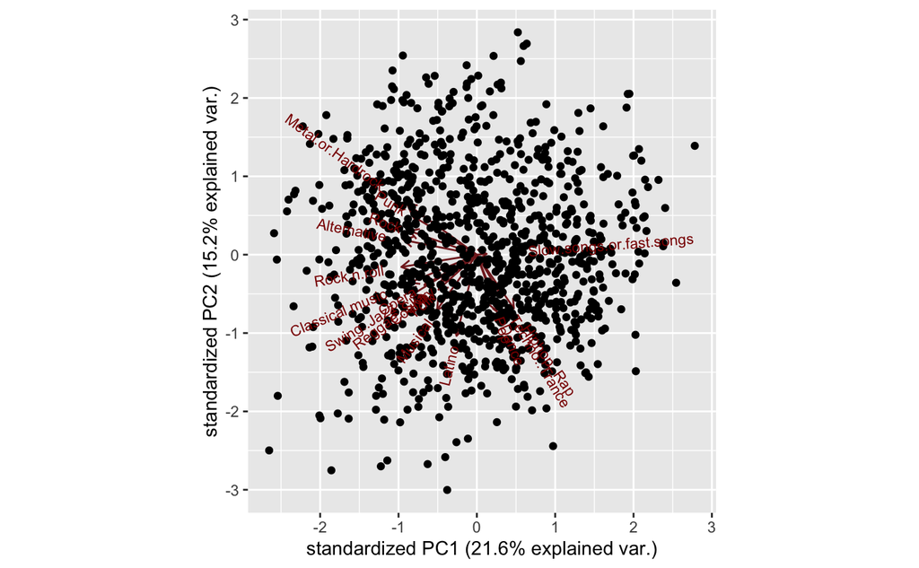

```r
ggbiplot(pca_music, choices = c(1,2))
```

## MOVIES

```r
pca_movies <- princomp(dat_movies)
summary(pca_movies)
```

```
Importance of components:
                          Comp.1    Comp.2    Comp.3     Comp.4     Comp.5     Comp.6
Standard deviation     1.9954651 1.6688109 1.4944776 1.18608035 1.08825250 1.03607121
Proportion of Variance 0.2433945 0.1702302 0.1365216 0.08599055 0.07239055 0.06561479
Cumulative Proportion  0.2433945 0.4136248 0.5501463 0.63613689 0.70852744 0.77414222
                           Comp.7     Comp.8     Comp.9    Comp.10    Comp.11
Standard deviation     1.02679437 0.94046985 0.86842309 0.72835816 0.68667993
Proportion of Variance 0.06444503 0.05406451 0.04609833 0.03242743 0.02882247
Cumulative Proportion  0.83858726 0.89265177 0.93875010 0.97117753 1.00000000
```

Observe que con las primeras tres componentes principales se alcanza una proporcion acumulada de varianza de poco mas de la mitad, lo cual no es del todo malo, si se deseara una mejor (80% +) tocaria tomar en cuenta las primeras 7 componentes principales, los scores de estas se muestran a continuacion

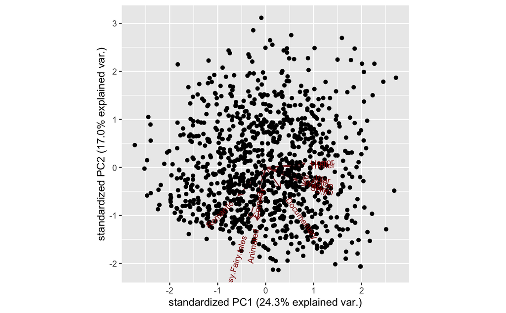

```r
ggbiplot(pca_movies, choices = c(1,2))
```

## HOBBIES

```r
pca_hobbies <- princomp(dat_hobbies)
summary(pca_hobbies)
```

```
Importance of components:
                          Comp.1    Comp.2     Comp.3     Comp.4     Comp.5     Comp.6
Standard deviation     2.7461378 2.3954083 2.09636120 1.97292733 1.69465662 1.54812429
Proportion of Variance 0.1337367 0.1017572 0.07793603 0.06902847 0.05092951 0.04250282
Cumulative Proportion  0.1337367 0.2354939 0.31342997 0.38245844 0.43338795 0.47589077
                           Comp.7    Comp.8     Comp.9    Comp.10    Comp.11    Comp.12
Standard deviation     1.51167492 1.4305814 1.37304232 1.33496224 1.28869562 1.25518717
Proportion of Variance 0.04052499 0.0362937 0.03343289 0.03160414 0.02945146 0.02793978
Cumulative Proportion  0.51641576 0.5527095 0.58614234 0.61774649 0.64719794 0.67513773
                          Comp.13    Comp.14    Comp.15    Comp.16    Comp.17    Comp.18
Standard deviation     1.22026197 1.19290971 1.15095651 1.12152649 1.10085176 1.06621820
Proportion of Variance 0.02640658 0.02523604 0.02349221 0.02230618 0.02149135 0.02016036
Cumulative Proportion  0.70154431 0.72678035 0.75027256 0.77257874 0.79407009 0.81423045
                          Comp.19    Comp.20    Comp.21    Comp.22    Comp.23    Comp.24
Standard deviation     1.04380867 1.02711569 0.96500106 0.94034536 0.92797879 0.91041720
Proportion of Variance 0.01932181 0.01870875 0.01651436 0.01568126 0.01527152 0.01469897
Cumulative Proportion  0.83355226 0.85226101 0.86877537 0.88445663 0.89972814 0.91442711
                          Comp.25   Comp.26    Comp.27    Comp.28    Comp.29     Comp.30
Standard deviation     0.88269541 0.8362529 0.82449705 0.76683364 0.74872564 0.739700101
Proportion of Variance 0.01381745 0.0124017 0.01205547 0.01042818 0.00994149 0.009703255
Cumulative Proportion  0.92824456 0.9406463 0.95270174 0.96312992 0.97307141 0.982774660
                           Comp.31     Comp.32
Standard deviation     0.715119096 0.678176474
Proportion of Variance 0.009069071 0.008156268
Cumulative Proportion  0.991843732 1.000000000
```

Observe que si se quiere un 80% de varianza acumulada se necesitan al menos 18 componentes principales.

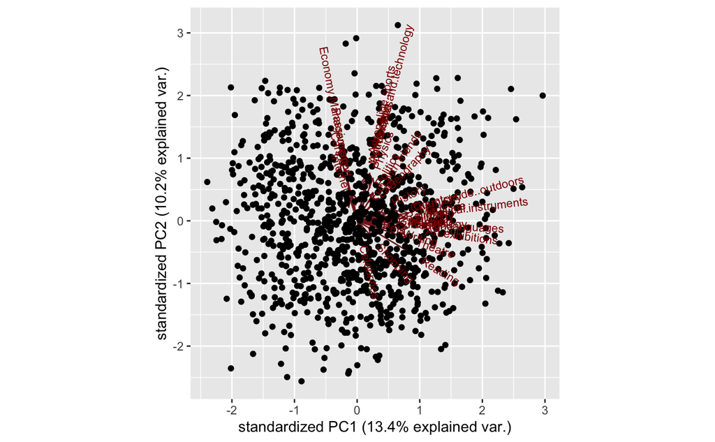

```r
ggbiplot(pca_hobbies, choices = c(1,2))
```

Podemos ver que con las primeras dos componentes principales no se alcanza a explicar ni siquiera el 30% de la varianza total de los datos.

# FA - ANALISIS DE FACTORES

Se busca hacer un analisis de factores para cada uno de los data frames mencionados a lo largo de este notebook, para esto se utilizara la funcion factanal que utiliza el metodo MLE y con una rotación varimax, este proceso se muestra a continuación

## MUSICA

```r
(fit <- factanal(dat_music,11,rotation="varimax"))
```

[output not shown]

```r
load <- fit$loadings[,1:2]
plot(load,type="n") # set up plot
text(load,labels=names(dat_music),cex=.7) # add variable names
```

[output not shown]

## MOVIES

```r
(fit <- factanal(dat_movies,6,rotation="varimax"))
```

[output not shown]

```r
load <- fit$loadings[,1:2]
plot(load,type="n") # set up plot
text(load,labels=names(dat_movies),cex=.7) # add variable names
```

[output not shown]

## HOBBIES

```r
(fit <- factanal(dat_hobbies,18,rotation="varimax"))
```

[output not shown]

```r
load <- fit$loadings[,1:2]
plot(load,type="n") # set up plot
text(load,labels=names(dat_hobbies),cex=.7) # add variable names
```

[output not shown]

Un analisis mucho mas detallado de la información presentada a lo largo de este notebook se encuentra en el documento.